# Gulf of Maine Seasonal Sea Surface Temperature Update

Seasonal Patterns in Sea Surface Temperatures

Author

Adam Kemberling

Published

October 24, 2025

# Summer 2025 Highlights

For this seasonal report we present an analysis of sea surface temperature (SST) for summer 2025, defined as the period extending from (June 1, 2025 - August 31, 2025).

This year, the average SST for the Gulf of Maine was 59.94°F. This seasonal average temperature was 0.83°F above the 1991–2020 climatological reference period (CRP) summer average of 59.10°F.

## Weekly Temperatures

Table 1 highlights how the SST for each week this summer compares to the 1991-2020 CRP for the area shown in Figure 7. The observed SST, long-term average SST, and SST anomalies (i.e., departures from the long-term average SST) are shown.

Weekly Average Sea Surface Temperatures - Summer

(June 1, 2025 - August 31, 2025)

| One-Week Period | Observed Temperature | Climatological Average | Temperature Anomaly |
| --- | --- | --- | --- |
| *Jun 01 - Jun 07* | 51.07°F *(10.60°C)* | 50.53°F *(10.29°C)* | 0.55°F *(0.30°C)* |
| *Jun 08 - Jun 14* | 52.65°F *(11.47°C)* | 52.28°F *(11.27°C)* | 0.36°F *(0.20°C)* |
| *Jun 15 - Jun 21* | 55.16°F *(12.87°C)* | 54.12°F *(12.29°C)* | 1.05°F *(0.58°C)* |
| *Jun 22 - Jun 28* | 57.28°F *(14.04°C)* | 55.97°F *(13.32°C)* | 1.30°F *(0.72°C)* |
| *Jun 29 - Jul 05* | 58.86°F *(14.92°C)* | 57.75°F *(14.31°C)* | 1.10°F *(0.61°C)* |
| *Jul 06 - Jul 12* | 61.12°F *(16.18°C)* | 59.34°F *(15.19°C)* | 1.78°F *(0.99°C)* |
| *Jul 13 - Jul 19* | 63.14°F *(17.30°C)* | 60.65°F *(15.92°C)* | 2.49°F *(1.38°C)* |
| *Jul 20 - Jul 26* | 62.33°F *(16.85°C)* | 61.73°F *(16.51°C)* | 0.60°F *(0.33°C)* |
| *Jul 27 - Aug 02* | 62.90°F *(17.16°C)* | 62.54°F *(16.97°C)* | 0.35°F *(0.20°C)* |
| *Aug 03 - Aug 09* | 62.96°F *(17.20°C)* | 63.10°F *(17.28°C)* | -0.14°F *(-0.08°C)* |
| *Aug 10 - Aug 16* | 64.87°F *(18.26°C)* | 63.38°F *(17.43°C)* | 1.49°F *(0.83°C)* |
| *Aug 17 - Aug 23* | 63.04°F *(17.24°C)* | 63.34°F *(17.41°C)* | -0.30°F *(-0.17°C)* |
| *Aug 24 - Aug 31* | 63.37°F *(17.43°C)* | 63.05°F *(17.25°C)* | 0.32°F *(0.18°C)* |
| *Aug 31 - Aug 31* | 62.86°F *(17.14°C)* | 62.80°F *(17.11°C)* | 0.06°F *(0.03°C)* |

*Data Source: NOAA OISSTv2 Daily Sea Surface Temperature Data.*  
*Climatological Reference Period: 1991-2020.*

Table 1: Average weekly sea surface temperatures in the Gulf of Maine

## Monthly Statistics

Table 2 shows monthly average SST for summer 2025. Each month has been ranked against all previous years from warmest (1), to lowest based on average temperature. The long-term climatological average, and the difference between observed SST’s and those averages are also reported.

Monthly Average Sea Surface Temperatures - Summer

(June 1, 2025 - August 31, 2025)

| Month | Rank (1982-2025) | Observed Temperature | Climatological Average | Temperature Anomaly |
| --- | --- | --- | --- | --- |
| *June* | 15 | 54.28°F *(12.38°C)* | 53.49°F *(11.94°C)* | 0.79°F *(0.44°C)* |
| *July* | 11 | 61.87°F *(16.59°C)* | 60.46°F *(15.81°C)* | 1.41°F *(0.78°C)* |
| *August* | 20 | 63.48°F *(17.49°C)* | 63.18°F *(17.32°C)* | 0.30°F *(0.17°C)* |

*Data Source: NOAA OISSTv2 Daily Sea Surface Temperature Data.*  
*Climatological Reference Period: 1991-2020.*

Table 2: Average monthly sea surface temperatures in the Gulf of Maine

## How Does this Summer Compare to the Past?

2025 was the 15th warmest (30th coldest) summer season observed in the Gulf of Maine during the 42+ years we have satellite data to analyze. Its position among years ranked more-highly is displayed below in Figure 1.

[figure not shown]

## Seasonal Trends and Long-Term Global Context

The Gulf of Maine is an area of particular interest to the scientific community because of the remarkable rate of warming it has experienced in recent years, coupled with its importance as a major driver for the regional economy.

Figure 2 illustrates the average summer temperature anomaly for each year in the Gulf of Maine since the beginning of the satellite record in 1982 overlaid with long-term SST anomaly trends for the Gulf of Maine (orange) and global oceans (blue) overlaid.

[figure not shown]

## Heatwave and Coldspell Conditions

The most commonly used definition of a [“marine heatwave” (MHW)](http://www.marineheatwaves.org/all-about-mhws.html) is when daily average SST’s exceeded the 90th percentile of a climatological (i.e., 30-year) average for at least 5 consecutive days. Gaps of 2 days or less in this threshold do not constitute a break in the MHW event.

Using this broadly accepted definition, **the Gulf of Maine has experienced MHW conditions for 0% of days this summer**.

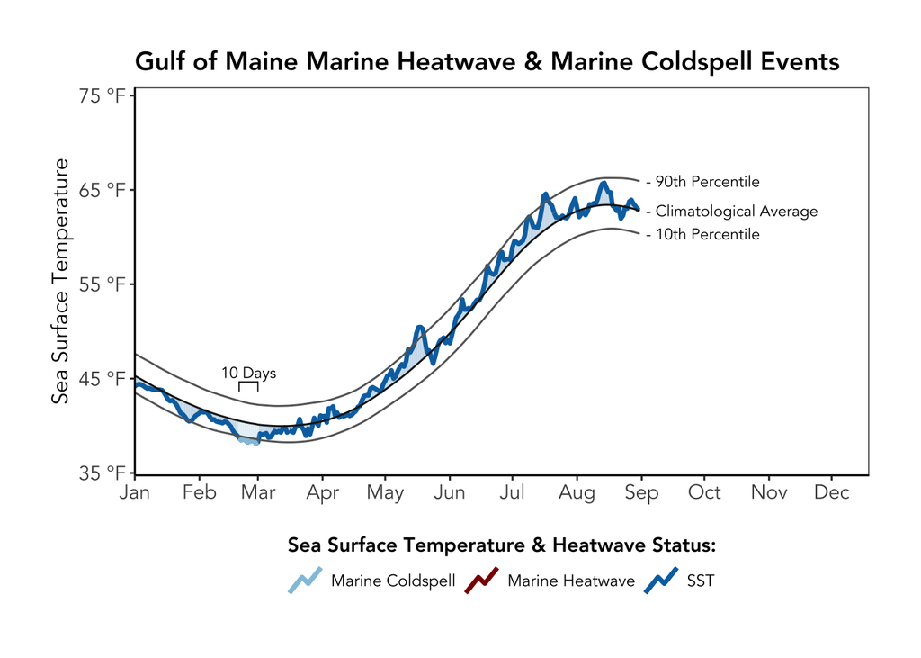

## Alternative Approaches for MHW Identification

The way extreme events are identified has become a topic of discussion, and the merits of using a fixed climatological baseline under a changing climate are being questioned.

With waters warming over time due to climate change, the use of a fixed climatological baseline can lead to a predictable pattern in hot and cold extreme events. Under warming, extreme cold events cluster at the beginning of timeseries, and extreme heat events cluster towards recent years.

There is a tradeoff in choosing between these two approaches (fixed baselines vs. adaptive thresholds). Under the fixed baseline approach there is an importance that temperatures have moved away from long-term conditions.

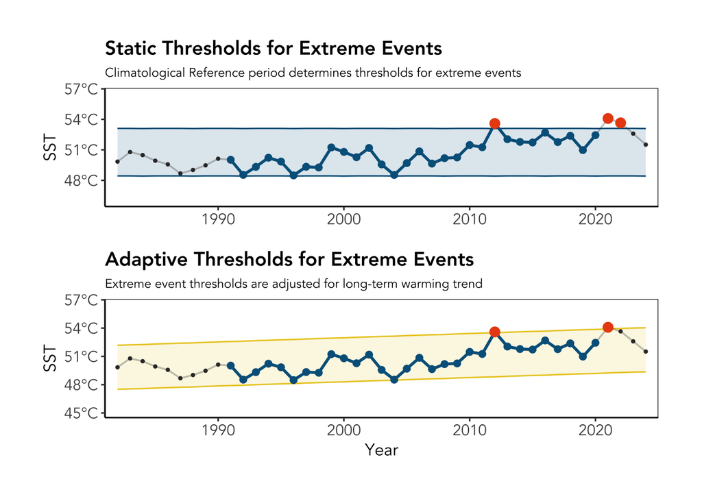

## Temperature Anomalies and Extreme Events

Looking at the full record of daily SST anomalies in the Gulf of Maine (Figure 4), the distinct thermal regime shift beginning around 2010 is evident.

If we use the standard MHW definition, where heatwaves and coldspells are determined using a static 30-year baseline we get one record of these extreme events. This has traditionally been the record we’ve reported on, and has a predictable pattern of more MHW events in recent years.

If instead, we adopt an approach which removes the long-term warming trend we get a slightly different figure. After removal of the long-term linear trend a “cold period” emerges prior to the sudden warming in 2010, immediately followed by MHW events in 2010 & 2012.

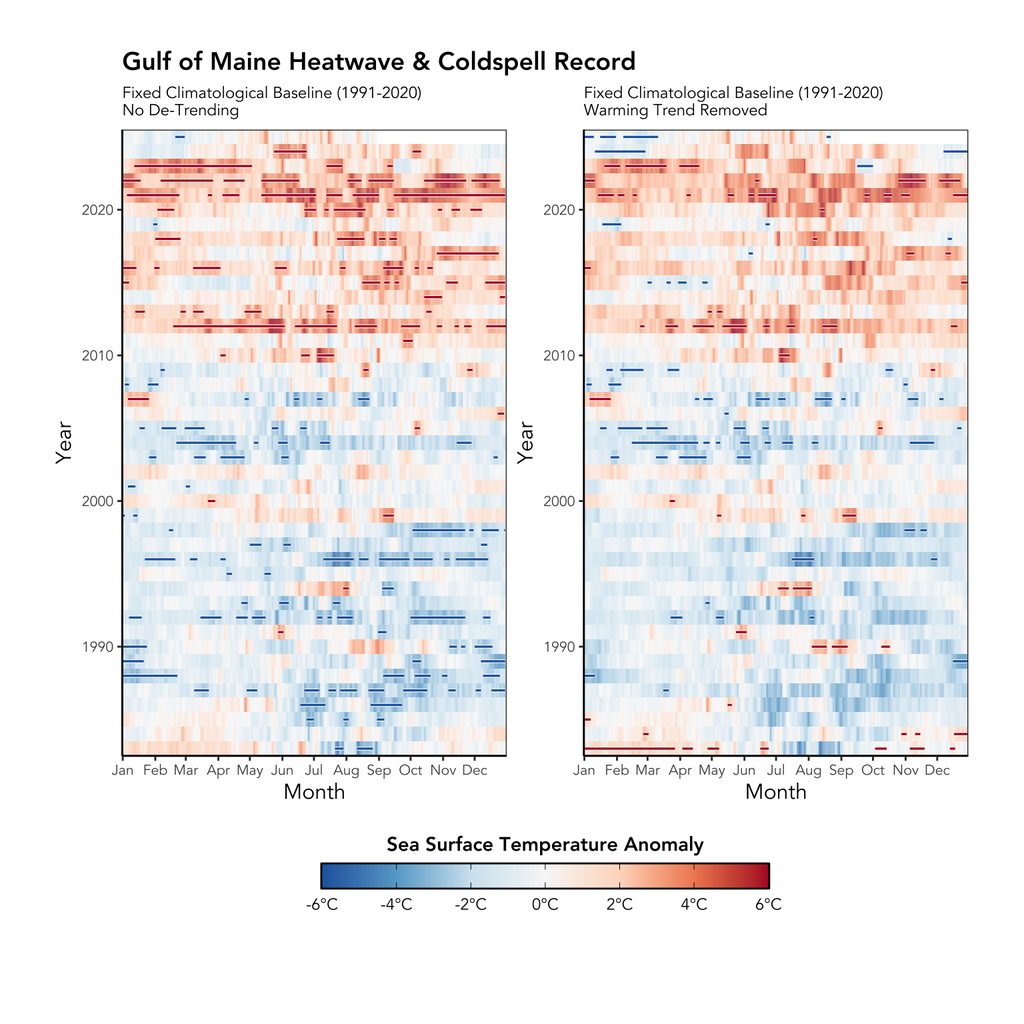

Figure 4: Heat maps of daily SST anomalies from a 30-year 1991-2020 climatological baseline. Marine heatwave events (red lines) and marine coldspell events (blue lines) contrasting two competing methodologies have been overlaid.

A comparison of the two above approaches shows that the methodology choices will ultimately impact the MHW/MCS record for the region.

Long-term linear trends can be thought of as a ramp, with a steady rise over time. The slope of the ramp is estimated using all the change over the full time period, and a single slope is returned. This slope is then removed from the whole timeseries.

The sudden increase in SSTs which happened in 2010 and which persisted over the next ~13 years has a charactistic “stair-step” shape, not the steady sustained climb a linear trend would capture. When using the MHW approach which removes the linear-trend, the periods immediately before and after the stair-step are highlighted as extreme events.

There is ongoing debate on the merits of either approach, and discussions on whether regional dynamics (e.g. the North Atlantic Oscillation, ENSO, Gulf Stream Position) should be accounted for when identifying marine heatwaves.

For now, I’ve presented both for comparison. Both approaches are valid approaches, but this side-by-side comparison should highlight how our senses of the occurrence and severity of extreme events is dependent on the approaches used.

## Spatial Distribution of Seasonal Anomalies

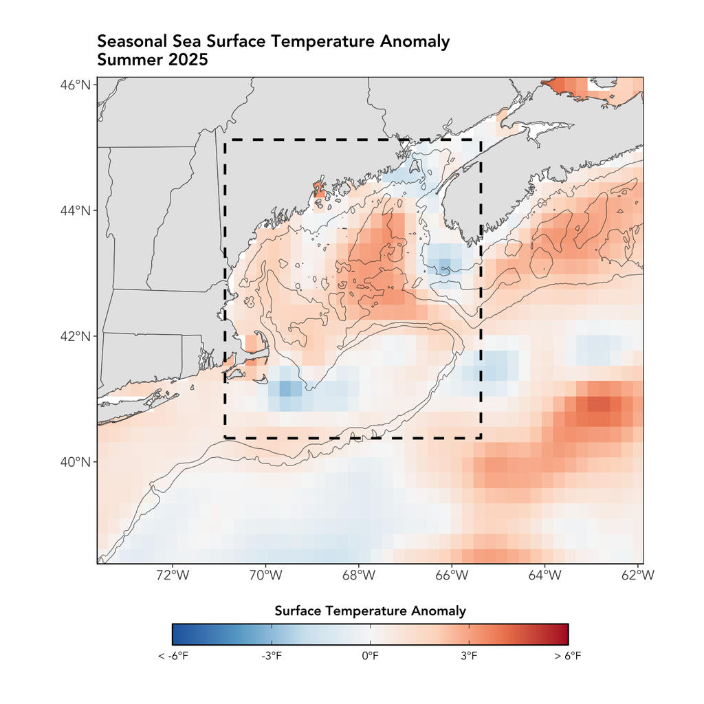

## Monthly Temperature Anomalies

The aerial distributions of average monthly SST anomalies are shown in Figure 6.

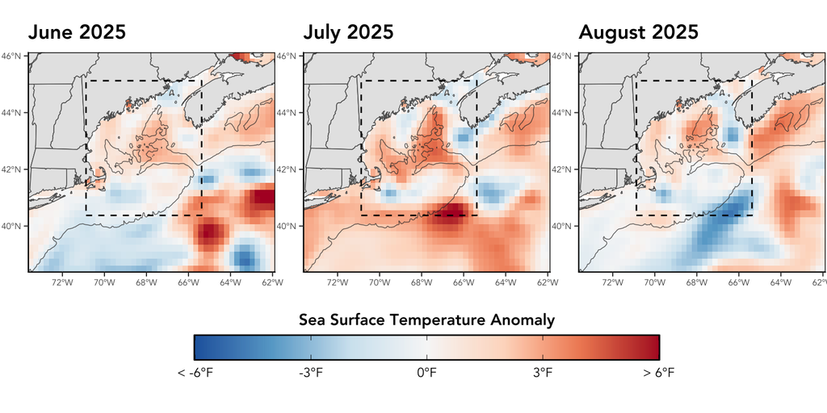

### Checking Bottom Temperatures

There is a growing understanding that local oceanographic dynamics in the Gulf of Maine are influenced by the relative mixtures of water masses entering the Gulf of Maine.

There are two primary deep-water masses entering the Gulf of Maine which enter the area through the Northeast Channel: 1. “Warm Slope Water” (WSW), which is positioned between the Gulf Stream and the continent shelf break 2. “Labrador Slope Water” (LSW) which is an extension of the labrador current and flows southwest following the scotian shelf shelf-break.

There is also a third off-shelf water mass, the “Gulf Stream Water” (GSW), which as its name implies closely follows the Gulf Stream position. GSW contributes less directly to the mixed water entering the Gulf of Maine, but there is evidence of it directly contributing to the NE channel inflow.

Closer to shore, on the landward side of the LSW over the continental shelf, more cold-water is transported along Scotian Shelf (SS). SS water follows the coastline of Nova Scotia and enters the Gulf of Maine before continuing up towards the Bay of Fundy.

These water masses each have different temperature, salinity, nutrient, and plankton community characteristics which all play a role in shaping downstream Gulf of Maine characteristics.

If we follow the bottom temperatures of the Gulf of Maine we can get some proxy of whether the inflow through the Northeast Channel favoring more WSW vs. LSW.

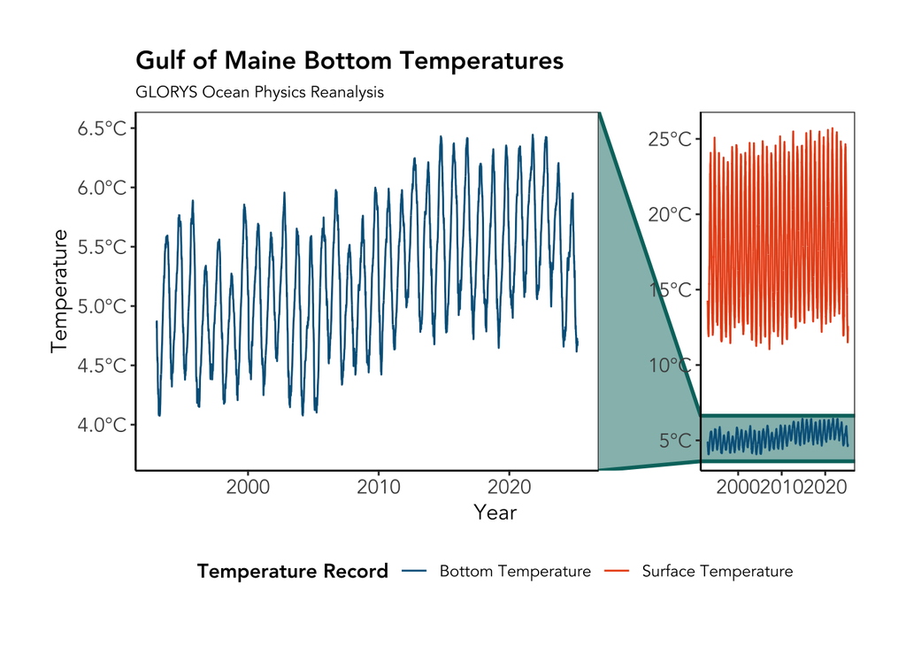

## About the Updates:

Over the past decade, scientists have led a body of research that highlights the rapid pace of warming in the Gulf of Maine. To help keep you informed, we share seasonal and annual updates about conditions in the Gulf of Maine. For a full compilation of all of GMRI’s seasonal and annual Gulf of Maine warming updates, visit: https://gmri.org/warmingupdates/.

## The Gulf of Maine Region

For analyses like these, it is important to be clear about the spatial extent that “defines” the Gulf of Maine (Figure 7), as different borders could produce different results. The spatial domain we use as the “Gulf of Maine” is outlined with the dashed line below. This area is consistent with previous seasonal and annual SST reports that scientists at GMRI have produced.

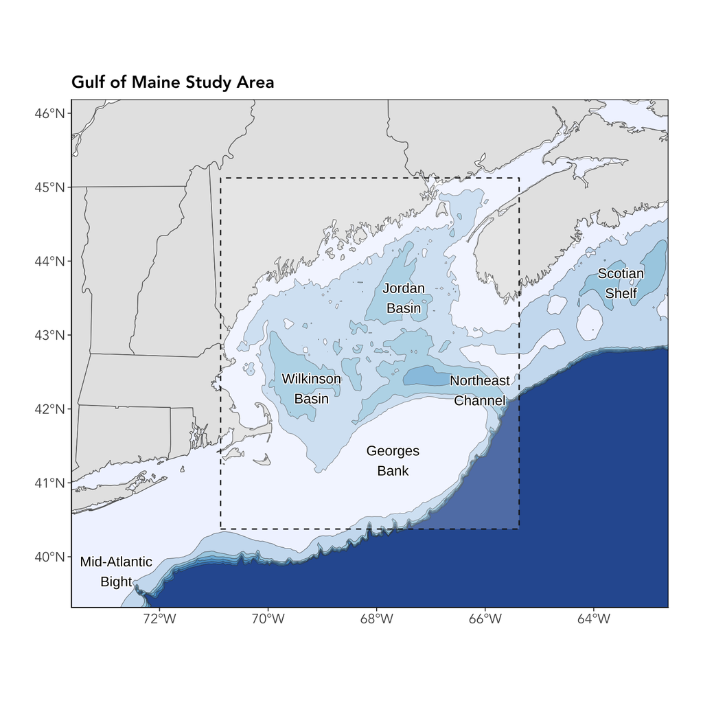

Figure 7: Spatial domain used for Gulf of Maine SST analyses. Depth contours are colored at 100 m intervals up to 600 m; deeper blues indicate deeper water depths

### Data Sources:

> NOAA High Resolution SST data provided by the NOAA/OAR/ESRL PSL, Boulder, Colorado, USA, from their Web site at https://psl.noaa.gov/data/gridded/data.noaa.oisst.v2.highres.html.

### Citing This Work

If you would like to cite this report, please use:

> Gulf of Maine Research Institute. 2025. Gulf of Maine Warming Update: Summer 2025

### Note About the Data:

The figures in this report are created using remotely-sensed satellite data as part of publicly funded research efforts. Satellite SST data was obtained from NOAA’s National Center for Environmental Information (NCEI), with all maps and figures displaying NOAA’s Optimum Interpolation Sea Surface Temperature Data.

> **Note About the Data:** The figures in this report are created using remotely-sensed satellite data as part of publicly funded research efforts. Satellite SST data was obtained from NOAA’s National Center for Environmental Information (NCEI), with all maps and figures displaying [NOAA’s Optimum Interpolation Sea Surface Temperature Data](https://www.ncei.noaa.gov/products/optimum-interpolation-sst).

A work by [Adam A. Kemberling](https://github.com/adamkemberling/)

*Akemberling@gmri.org*